# Risk Factor Analysis

## Outcome Variable

**Outcome Variable:** stunted

## Predictor Variables

**Intervention Variable:** single

**Adjustment Set:**

- arm
- W_mage
- meducyrs
- feducyrs
- W_mhtcm
- W_mwtkg
- W_mbmi
- delta_W_mage
- delta_meducyrs
- delta_feducyrs
- delta_W_mhtcm
- delta_W_mwtkg
- delta_W_mbmi

## Stratifying Variables

The analysis was stratified on these variable(s):

- agecat
- studyid
- country

## Data Summary

| agecat | studyid | country | single | stunted | n_cell | n |
| --- | --- | --- | --- | --- | --- | --- |
| Birth | ki0047075b-MAL-ED | BANGLADESH | 0 | 0 | 187 | 231 |
| Birth | ki0047075b-MAL-ED | BANGLADESH | 0 | 1 | 44 | 231 |
| Birth | ki0047075b-MAL-ED | BANGLADESH | 1 | 0 | 0 | 231 |
| Birth | ki0047075b-MAL-ED | BANGLADESH | 1 | 1 | 0 | 231 |
| Birth | ki0047075b-MAL-ED | BRAZIL | 0 | 0 | 51 | 65 |
| Birth | ki0047075b-MAL-ED | BRAZIL | 0 | 1 | 6 | 65 |
| Birth | ki0047075b-MAL-ED | BRAZIL | 1 | 0 | 5 | 65 |
| Birth | ki0047075b-MAL-ED | BRAZIL | 1 | 1 | 3 | 65 |
| Birth | ki0047075b-MAL-ED | INDIA | 0 | 0 | 37 | 47 |
| Birth | ki0047075b-MAL-ED | INDIA | 0 | 1 | 10 | 47 |
| Birth | ki0047075b-MAL-ED | INDIA | 1 | 0 | 0 | 47 |
| Birth | ki0047075b-MAL-ED | INDIA | 1 | 1 | 0 | 47 |
| Birth | ki0047075b-MAL-ED | NEPAL | 0 | 0 | 25 | 27 |
| Birth | ki0047075b-MAL-ED | NEPAL | 0 | 1 | 2 | 27 |
| Birth | ki0047075b-MAL-ED | NEPAL | 1 | 0 | 0 | 27 |
| Birth | ki0047075b-MAL-ED | NEPAL | 1 | 1 | 0 | 27 |
| Birth | ki0047075b-MAL-ED | PERU | 0 | 0 | 187 | 233 |
| Birth | ki0047075b-MAL-ED | PERU | 0 | 1 | 22 | 233 |
| Birth | ki0047075b-MAL-ED | PERU | 1 | 0 | 20 | 233 |
| Birth | ki0047075b-MAL-ED | PERU | 1 | 1 | 4 | 233 |
| Birth | ki0047075b-MAL-ED | SOUTH AFRICA | 0 | 0 | 60 | 123 |
| Birth | ki0047075b-MAL-ED | SOUTH AFRICA | 0 | 1 | 3 | 123 |
| Birth | ki0047075b-MAL-ED | SOUTH AFRICA | 1 | 0 | 53 | 123 |
| Birth | ki0047075b-MAL-ED | SOUTH AFRICA | 1 | 1 | 7 | 123 |
| Birth | ki0047075b-MAL-ED | TANZANIA, UNITED REPUBLIC OF | 0 | 0 | 99 | 125 |
| Birth | ki0047075b-MAL-ED | TANZANIA, UNITED REPUBLIC OF | 0 | 1 | 23 | 125 |
| Birth | ki0047075b-MAL-ED | TANZANIA, UNITED REPUBLIC OF | 1 | 0 | 3 | 125 |
| Birth | ki0047075b-MAL-ED | TANZANIA, UNITED REPUBLIC OF | 1 | 1 | 0 | 125 |
| Birth | ki1119695-PROBIT | BELARUS | 0 | 0 | 13317 | 13890 |
| Birth | ki1119695-PROBIT | BELARUS | 0 | 1 | 31 | 13890 |

[output cut: 138 more lines]

The following strata were considered:

- agecat: 24 months, studyid: ki0047075b-MAL-ED, country: BANGLADESH
- agecat: 24 months, studyid: ki0047075b-MAL-ED, country: BRAZIL
- agecat: 24 months, studyid: ki0047075b-MAL-ED, country: INDIA
- agecat: 24 months, studyid: ki0047075b-MAL-ED, country: NEPAL
- agecat: 24 months, studyid: ki0047075b-MAL-ED, country: PERU
- agecat: 24 months, studyid: ki0047075b-MAL-ED, country: SOUTH AFRICA
- agecat: 24 months, studyid: ki0047075b-MAL-ED, country: TANZANIA, UNITED REPUBLIC OF
- agecat: 24 months, studyid: ki1066203-TanzaniaChild2, country: TANZANIA, UNITED REPUBLIC OF
- agecat: 24 months, studyid: ki1119695-PROBIT, country: BELARUS
- agecat: 24 months, studyid: ki1126311-ZVITAMBO, country: ZIMBABWE
- agecat: 24 months, studyid: ki1135781-COHORTS, country: GUATEMALA
- agecat: 24 months, studyid: ki1135781-COHORTS, country: INDIA
- agecat: 24 months, studyid: ki1135781-COHORTS, country: PHILIPPINES
- agecat: 24 months, studyid: kiGH5241-JiVitA-4, country: BANGLADESH
- agecat: 6 months, studyid: ki0047075b-MAL-ED, country: BANGLADESH
- agecat: 6 months, studyid: ki0047075b-MAL-ED, country: BRAZIL
- agecat: 6 months, studyid: ki0047075b-MAL-ED, country: INDIA
- agecat: 6 months, studyid: ki0047075b-MAL-ED, country: NEPAL
- agecat: 6 months, studyid: ki0047075b-MAL-ED, country: PERU
- agecat: 6 months, studyid: ki0047075b-MAL-ED, country: SOUTH AFRICA
- agecat: 6 months, studyid: ki0047075b-MAL-ED, country: TANZANIA, UNITED REPUBLIC OF
- agecat: 6 months, studyid: ki1066203-TanzaniaChild2, country: TANZANIA, UNITED REPUBLIC OF
- agecat: 6 months, studyid: ki1112895-Guatemala BSC, country: GUATEMALA
- agecat: 6 months, studyid: ki1119695-PROBIT, country: BELARUS
- agecat: 6 months, studyid: ki1126311-ZVITAMBO, country: ZIMBABWE
- agecat: 6 months, studyid: ki1135781-COHORTS, country: GUATEMALA
- agecat: 6 months, studyid: ki1135781-COHORTS, country: INDIA
- agecat: 6 months, studyid: ki1135781-COHORTS, country: PHILIPPINES
- agecat: 6 months, studyid: kiGH5241-JiVitA-4, country: BANGLADESH
- agecat: Birth, studyid: ki0047075b-MAL-ED, country: BANGLADESH
- agecat: Birth, studyid: ki0047075b-MAL-ED, country: BRAZIL
- agecat: Birth, studyid: ki0047075b-MAL-ED, country: INDIA
- agecat: Birth, studyid: ki0047075b-MAL-ED, country: NEPAL
- agecat: Birth, studyid: ki0047075b-MAL-ED, country: PERU
- agecat: Birth, studyid: ki0047075b-MAL-ED, country: SOUTH AFRICA
- agecat: Birth, studyid: ki0047075b-MAL-ED, country: TANZANIA, UNITED REPUBLIC OF
- agecat: Birth, studyid: ki1119695-PROBIT, country: BELARUS
- agecat: Birth, studyid: ki1126311-ZVITAMBO, country: ZIMBABWE
- agecat: Birth, studyid: ki1135781-COHORTS, country: GUATEMALA
- agecat: Birth, studyid: ki1135781-COHORTS, country: INDIA
- agecat: Birth, studyid: ki1135781-COHORTS, country: PHILIPPINES
- agecat: Birth, studyid: kiGH5241-JiVitA-4, country: BANGLADESH

### Dropped Strata

Some strata were dropped due to rare outcomes:

- agecat: Birth, studyid: ki0047075b-MAL-ED, country: BANGLADESH
- agecat: Birth, studyid: ki0047075b-MAL-ED, country: BRAZIL
- agecat: Birth, studyid: ki0047075b-MAL-ED, country: INDIA
- agecat: Birth, studyid: ki0047075b-MAL-ED, country: NEPAL
- agecat: Birth, studyid: ki0047075b-MAL-ED, country: PERU
- agecat: Birth, studyid: ki0047075b-MAL-ED, country: SOUTH AFRICA
- agecat: Birth, studyid: ki0047075b-MAL-ED, country: TANZANIA, UNITED REPUBLIC OF
- agecat: Birth, studyid: ki1119695-PROBIT, country: BELARUS
- agecat: Birth, studyid: ki1135781-COHORTS, country: INDIA
- agecat: Birth, studyid: kiGH5241-JiVitA-4, country: BANGLADESH
- agecat: 6 months, studyid: ki0047075b-MAL-ED, country: BANGLADESH
- agecat: 6 months, studyid: ki0047075b-MAL-ED, country: BRAZIL
- agecat: 6 months, studyid: ki0047075b-MAL-ED, country: INDIA
- agecat: 6 months, studyid: ki0047075b-MAL-ED, country: NEPAL
- agecat: 6 months, studyid: ki0047075b-MAL-ED, country: TANZANIA, UNITED REPUBLIC OF
- agecat: 6 months, studyid: ki1135781-COHORTS, country: INDIA
- agecat: 6 months, studyid: kiGH5241-JiVitA-4, country: BANGLADESH
- agecat: 24 months, studyid: ki0047075b-MAL-ED, country: BANGLADESH
- agecat: 24 months, studyid: ki0047075b-MAL-ED, country: BRAZIL
- agecat: 24 months, studyid: ki0047075b-MAL-ED, country: INDIA
- agecat: 24 months, studyid: ki0047075b-MAL-ED, country: NEPAL
- agecat: 24 months, studyid: ki0047075b-MAL-ED, country: TANZANIA, UNITED REPUBLIC OF
- agecat: 24 months, studyid: ki1066203-TanzaniaChild2, country: TANZANIA, UNITED REPUBLIC OF
- agecat: 24 months, studyid: ki1135781-COHORTS, country: INDIA
- agecat: 24 months, studyid: kiGH5241-JiVitA-4, country: BANGLADESH

## Methods Detail

We’re interested in the causal parameters $E[Y_a]$ for all values of $a \in \mathcal{A}$. These parameters represent the mean outcome if, possibly contrary to fact, we intervened to set all units to have $A=a$. Under the randomization and positivity assumptions, these are identified by the statistical parameters $\psi_a=E_W[E_{Y|A,W}(Y|A=a,W)]$. In addition, we’re interested in the mean of $Y$, $E[Y]$ under no intervention (the observed mean). We will estimate these parameters by using SuperLearner to fit the relevant likelihood factors – $E_{Y|A,W}(Y|A=a,W)$ and $p(A=a|W)$, and then updating our likelihood fit using a joint TMLE.

For unadjusted analyses ($W=\{\}$), initial likelihoods were estimated using Lrnr_glm to estimate the simple $E(Y|A)$ and Lrnr_mean to estimate $p(A)$. For adjusted analyses, a small library containing Lrnr_glmnet, Lrnr_xgboost, and Lrnr_mean was used.

Having estimated these parameters, we will then use the delta method to estimate relative risks and attributable risks relative to a prespecified baseline level of $A$.

# Results Detail

## Results Plots

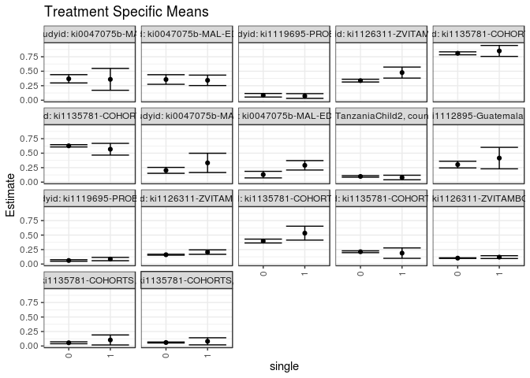

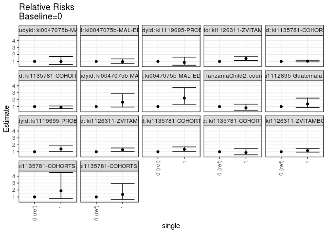

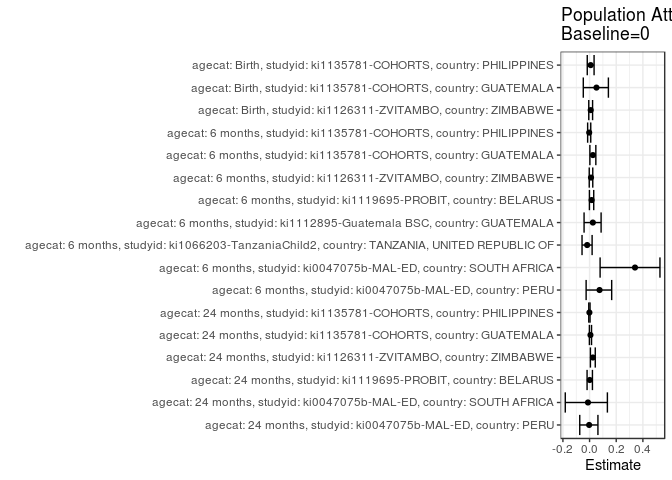

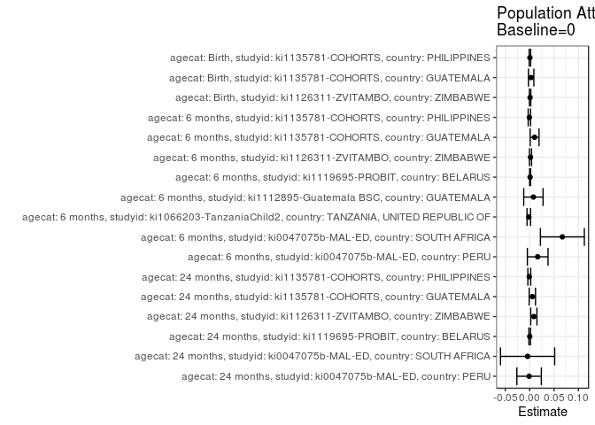

## Results Table

### Parameter: TSM

| agecat | studyid | country | intervention_level | baseline_level | estimate | ci_lower | ci_upper |
| --- | --- | --- | --- | --- | --- | --- | --- |
| Birth | ki1126311-ZVITAMBO | ZIMBABWE | 0 | NA | 0.1025525 | 0.0973018 | 0.1078033 |
| Birth | ki1126311-ZVITAMBO | ZIMBABWE | 1 | NA | 0.1197301 | 0.0951272 | 0.1443330 |
| Birth | ki1135781-COHORTS | GUATEMALA | 0 | NA | 0.0556328 | 0.0388678 | 0.0723978 |
| Birth | ki1135781-COHORTS | GUATEMALA | 1 | NA | 0.1041667 | 0.0176920 | 0.1906413 |
| Birth | ki1135781-COHORTS | PHILIPPINES | 0 | NA | 0.0599455 | 0.0513537 | 0.0685373 |
| Birth | ki1135781-COHORTS | PHILIPPINES | 1 | NA | 0.0810811 | 0.0199126 | 0.1422496 |
| 6 months | ki0047075b-MAL-ED | PERU | 0 | NA | 0.2032978 | 0.1523248 | 0.2542707 |
| 6 months | ki0047075b-MAL-ED | PERU | 1 | NA | 0.3321926 | 0.1658354 | 0.4985497 |
| 6 months | ki0047075b-MAL-ED | SOUTH AFRICA | 0 | NA | 0.1297599 | 0.0733518 | 0.1861681 |
| 6 months | ki0047075b-MAL-ED | SOUTH AFRICA | 1 | NA | 0.2902431 | 0.2087866 | 0.3716996 |
| 6 months | ki1066203-TanzaniaChild2 | TANZANIA, UNITED REPUBLIC OF | 0 | NA | 0.0986144 | 0.0849728 | 0.1122561 |
| 6 months | ki1066203-TanzaniaChild2 | TANZANIA, UNITED REPUBLIC OF | 1 | NA | 0.0797651 | 0.0403911 | 0.1191391 |
| 6 months | ki1112895-Guatemala BSC | GUATEMALA | 0 | NA | 0.3027811 | 0.2453184 | 0.3602438 |
| 6 months | ki1112895-Guatemala BSC | GUATEMALA | 1 | NA | 0.4151695 | 0.2300116 | 0.6003274 |
| 6 months | ki1119695-PROBIT | BELARUS | 0 | NA | 0.0617346 | 0.0479877 | 0.0754814 |
| 6 months | ki1119695-PROBIT | BELARUS | 1 | NA | 0.0864784 | 0.0578106 | 0.1151463 |
| 6 months | ki1126311-ZVITAMBO | ZIMBABWE | 0 | NA | 0.1611177 | 0.1530995 | 0.1691358 |
| 6 months | ki1126311-ZVITAMBO | ZIMBABWE | 1 | NA | 0.2065989 | 0.1684223 | 0.2447755 |
| 6 months | ki1135781-COHORTS | GUATEMALA | 0 | NA | 0.3974356 | 0.3641402 | 0.4307309 |
| 6 months | ki1135781-COHORTS | GUATEMALA | 1 | NA | 0.5333615 | 0.4131161 | 0.6536069 |
| 6 months | ki1135781-COHORTS | PHILIPPINES | 0 | NA | 0.2124608 | 0.1967205 | 0.2282012 |
| 6 months | ki1135781-COHORTS | PHILIPPINES | 1 | NA | 0.1887893 | 0.0991471 | 0.2784315 |
| 24 months | ki0047075b-MAL-ED | PERU | 0 | NA | 0.3693182 | 0.2978389 | 0.4407975 |
| 24 months | ki0047075b-MAL-ED | PERU | 1 | NA | 0.3600000 | 0.1713737 | 0.5486263 |
| 24 months | ki0047075b-MAL-ED | SOUTH AFRICA | 0 | NA | 0.3571810 | 0.2744822 | 0.4398798 |
| 24 months | ki0047075b-MAL-ED | SOUTH AFRICA | 1 | NA | 0.3431616 | 0.2529937 | 0.4333295 |
| 24 months | ki1119695-PROBIT | BELARUS | 0 | NA | 0.0851170 | 0.0543845 | 0.1158495 |
| 24 months | ki1119695-PROBIT | BELARUS | 1 | NA | 0.0725789 | 0.0321502 | 0.1130076 |
| 24 months | ki1126311-ZVITAMBO | ZIMBABWE | 0 | NA | 0.3378080 | 0.3141431 | 0.3614729 |
| 24 months | ki1126311-ZVITAMBO | ZIMBABWE | 1 | NA | 0.4768164 | 0.3815557 | 0.5720772 |
| 24 months | ki1135781-COHORTS | GUATEMALA | 0 | NA | 0.8093572 | 0.7840606 | 0.8346537 |
| 24 months | ki1135781-COHORTS | GUATEMALA | 1 | NA | 0.8503685 | 0.7557722 | 0.9449649 |
| 24 months | ki1135781-COHORTS | PHILIPPINES | 0 | NA | 0.6265852 | 0.6069756 | 0.6461949 |
| 24 months | ki1135781-COHORTS | PHILIPPINES | 1 | NA | 0.5678793 | 0.4662820 | 0.6694766 |

### Parameter: E(Y)

| agecat | studyid | country | intervention_level | baseline_level | estimate | ci_lower | ci_upper |
| --- | --- | --- | --- | --- | --- | --- | --- |
| Birth | ki1126311-ZVITAMBO | ZIMBABWE | NA | NA | 0.1034233 | 0.0983457 | 0.1085009 |
| Birth | ki1135781-COHORTS | GUATEMALA | NA | NA | 0.0586701 | 0.0420278 | 0.0753124 |
| Birth | ki1135781-COHORTS | PHILIPPINES | NA | NA | 0.0604651 | 0.0519489 | 0.0689813 |
| 6 months | ki0047075b-MAL-ED | PERU | NA | NA | 0.2197802 | 0.1705687 | 0.2689917 |
| 6 months | ki0047075b-MAL-ED | SOUTH AFRICA | NA | NA | 0.1968504 | 0.1478551 | 0.2458457 |
| 6 months | ki1066203-TanzaniaChild2 | TANZANIA, UNITED REPUBLIC OF | NA | NA | 0.0968703 | 0.0839461 | 0.1097946 |
| 6 months | ki1112895-Guatemala BSC | GUATEMALA | NA | NA | 0.3104693 | 0.2558835 | 0.3650551 |
| 6 months | ki1119695-PROBIT | BELARUS | NA | NA | 0.0626864 | 0.0488489 | 0.0765238 |
| 6 months | ki1126311-ZVITAMBO | ZIMBABWE | NA | NA | 0.1628849 | 0.1550974 | 0.1706725 |
| 6 months | ki1135781-COHORTS | GUATEMALA | NA | NA | 0.4076148 | 0.3753675 | 0.4398620 |
| 6 months | ki1135781-COHORTS | PHILIPPINES | NA | NA | 0.2118834 | 0.1963977 | 0.2273691 |
| 24 months | ki0047075b-MAL-ED | PERU | NA | NA | 0.3681592 | 0.3013164 | 0.4350020 |
| 24 months | ki0047075b-MAL-ED | SOUTH AFRICA | NA | NA | 0.3529412 | 0.2921001 | 0.4137823 |
| 24 months | ki1119695-PROBIT | BELARUS | NA | NA | 0.0852540 | 0.0554439 | 0.1150642 |
| 24 months | ki1126311-ZVITAMBO | ZIMBABWE | NA | NA | 0.3463653 | 0.3233089 | 0.3694217 |
| 24 months | ki1135781-COHORTS | GUATEMALA | NA | NA | 0.8148515 | 0.7908851 | 0.8388178 |
| 24 months | ki1135781-COHORTS | PHILIPPINES | NA | NA | 0.6258278 | 0.6065280 | 0.6451276 |

### Parameter: RR

| agecat | studyid | country | intervention_level | baseline_level | estimate | ci_lower | ci_upper |
| --- | --- | --- | --- | --- | --- | --- | --- |
| Birth | ki1126311-ZVITAMBO | ZIMBABWE | 0 | 0 | 1.0000000 | 1.0000000 | 1.000000 |
| Birth | ki1126311-ZVITAMBO | ZIMBABWE | 1 | 0 | 1.1674996 | 0.9446844 | 1.442869 |
| Birth | ki1135781-COHORTS | GUATEMALA | 0 | 0 | 1.0000000 | 1.0000000 | 1.000000 |
| Birth | ki1135781-COHORTS | GUATEMALA | 1 | 0 | 1.8723958 | 0.7741873 | 4.528447 |
| Birth | ki1135781-COHORTS | PHILIPPINES | 0 | 0 | 1.0000000 | 1.0000000 | 1.000000 |
| Birth | ki1135781-COHORTS | PHILIPPINES | 1 | 0 | 1.3525799 | 0.6275750 | 2.915145 |
| 6 months | ki0047075b-MAL-ED | PERU | 0 | 0 | 1.0000000 | 1.0000000 | 1.000000 |
| 6 months | ki0047075b-MAL-ED | PERU | 1 | 0 | 1.6340197 | 0.9353862 | 2.854458 |
| 6 months | ki0047075b-MAL-ED | SOUTH AFRICA | 0 | 0 | 1.0000000 | 1.0000000 | 1.000000 |
| 6 months | ki0047075b-MAL-ED | SOUTH AFRICA | 1 | 0 | 2.2367697 | 1.3394641 | 3.735180 |
| 6 months | ki1066203-TanzaniaChild2 | TANZANIA, UNITED REPUBLIC OF | 0 | 0 | 1.0000000 | 1.0000000 | 1.000000 |
| 6 months | ki1066203-TanzaniaChild2 | TANZANIA, UNITED REPUBLIC OF | 1 | 0 | 0.8088584 | 0.4847015 | 1.349804 |
| 6 months | ki1112895-Guatemala BSC | GUATEMALA | 0 | 0 | 1.0000000 | 1.0000000 | 1.000000 |
| 6 months | ki1112895-Guatemala BSC | GUATEMALA | 1 | 0 | 1.3711868 | 0.8441012 | 2.227403 |
| 6 months | ki1119695-PROBIT | BELARUS | 0 | 0 | 1.0000000 | 1.0000000 | 1.000000 |
| 6 months | ki1119695-PROBIT | BELARUS | 1 | 0 | 1.4008104 | 1.0578432 | 1.854972 |
| 6 months | ki1126311-ZVITAMBO | ZIMBABWE | 0 | 0 | 1.0000000 | 1.0000000 | 1.000000 |
| 6 months | ki1126311-ZVITAMBO | ZIMBABWE | 1 | 0 | 1.2822860 | 1.0593365 | 1.552158 |
| 6 months | ki1135781-COHORTS | GUATEMALA | 0 | 0 | 1.0000000 | 1.0000000 | 1.000000 |
| 6 months | ki1135781-COHORTS | GUATEMALA | 1 | 0 | 1.3420075 | 1.0570837 | 1.703729 |
| 6 months | ki1135781-COHORTS | PHILIPPINES | 0 | 0 | 1.0000000 | 1.0000000 | 1.000000 |
| 6 months | ki1135781-COHORTS | PHILIPPINES | 1 | 0 | 0.8885840 | 0.5497018 | 1.436381 |
| 24 months | ki0047075b-MAL-ED | PERU | 0 | 0 | 1.0000000 | 1.0000000 | 1.000000 |
| 24 months | ki0047075b-MAL-ED | PERU | 1 | 0 | 0.9747692 | 0.5575963 | 1.704056 |
| 24 months | ki0047075b-MAL-ED | SOUTH AFRICA | 0 | 0 | 1.0000000 | 1.0000000 | 1.000000 |
| 24 months | ki0047075b-MAL-ED | SOUTH AFRICA | 1 | 0 | 0.9607498 | 0.6777591 | 1.361900 |
| 24 months | ki1119695-PROBIT | BELARUS | 0 | 0 | 1.0000000 | 1.0000000 | 1.000000 |
| 24 months | ki1119695-PROBIT | BELARUS | 1 | 0 | 0.8526954 | 0.4477765 | 1.623778 |
| 24 months | ki1126311-ZVITAMBO | ZIMBABWE | 0 | 0 | 1.0000000 | 1.0000000 | 1.000000 |
| 24 months | ki1126311-ZVITAMBO | ZIMBABWE | 1 | 0 | 1.4115012 | 1.1430990 | 1.742925 |
| 24 months | ki1135781-COHORTS | GUATEMALA | 0 | 0 | 1.0000000 | 1.0000000 | 1.000000 |
| 24 months | ki1135781-COHORTS | GUATEMALA | 1 | 0 | 1.0506715 | 0.9359842 | 1.179412 |
| 24 months | ki1135781-COHORTS | PHILIPPINES | 0 | 0 | 1.0000000 | 1.0000000 | 1.000000 |
| 24 months | ki1135781-COHORTS | PHILIPPINES | 1 | 0 | 0.9063082 | 0.7562294 | 1.086171 |

### Parameter: PAR

| agecat | studyid | country | intervention_level | baseline_level | estimate | ci_lower | ci_upper |
| --- | --- | --- | --- | --- | --- | --- | --- |
| Birth | ki1126311-ZVITAMBO | ZIMBABWE | 0 | NA | 0.0008708 | -0.0006095 | 0.0023511 |
| Birth | ki1135781-COHORTS | GUATEMALA | 0 | NA | 0.0030373 | -0.0025377 | 0.0086123 |
| Birth | ki1135781-COHORTS | PHILIPPINES | 0 | NA | 0.0005196 | -0.0010290 | 0.0020683 |
| 6 months | ki0047075b-MAL-ED | PERU | 0 | NA | 0.0164824 | -0.0047089 | 0.0376738 |
| 6 months | ki0047075b-MAL-ED | SOUTH AFRICA | 0 | NA | 0.0670905 | 0.0220466 | 0.1121343 |
| 6 months | ki1066203-TanzaniaChild2 | TANZANIA, UNITED REPUBLIC OF | 0 | NA | -0.0017441 | -0.0054109 | 0.0019227 |
| 6 months | ki1112895-Guatemala BSC | GUATEMALA | 0 | NA | 0.0076882 | -0.0121266 | 0.0275030 |
| 6 months | ki1119695-PROBIT | BELARUS | 0 | NA | 0.0009518 | -0.0000639 | 0.0019676 |
| 6 months | ki1126311-ZVITAMBO | ZIMBABWE | 0 | NA | 0.0017672 | -0.0003883 | 0.0039228 |
| 6 months | ki1135781-COHORTS | GUATEMALA | 0 | NA | 0.0101792 | 0.0011005 | 0.0192579 |
| 6 months | ki1135781-COHORTS | PHILIPPINES | 0 | NA | -0.0005774 | -0.0030476 | 0.0018927 |
| 24 months | ki0047075b-MAL-ED | PERU | 0 | NA | -0.0011590 | -0.0262516 | 0.0239336 |
| 24 months | ki0047075b-MAL-ED | SOUTH AFRICA | 0 | NA | -0.0042399 | -0.0597915 | 0.0513118 |
| 24 months | ki1119695-PROBIT | BELARUS | 0 | NA | 0.0001370 | -0.0015510 | 0.0018251 |
| 24 months | ki1126311-ZVITAMBO | ZIMBABWE | 0 | NA | 0.0085573 | 0.0022454 | 0.0148692 |
| 24 months | ki1135781-COHORTS | GUATEMALA | 0 | NA | 0.0054943 | -0.0010038 | 0.0119924 |
| 24 months | ki1135781-COHORTS | PHILIPPINES | 0 | NA | -0.0007574 | -0.0037140 | 0.0021992 |

### Parameter: PAF

| agecat | studyid | country | intervention_level | baseline_level | estimate | ci_lower | ci_upper |
| --- | --- | --- | --- | --- | --- | --- | --- |
| Birth | ki1126311-ZVITAMBO | ZIMBABWE | 0 | NA | 0.0084195 | -0.0059923 | 0.0226249 |
| Birth | ki1135781-COHORTS | GUATEMALA | 0 | NA | 0.0517694 | -0.0470659 | 0.1412754 |
| Birth | ki1135781-COHORTS | PHILIPPINES | 0 | NA | 0.0085936 | -0.0173296 | 0.0338562 |
| 6 months | ki0047075b-MAL-ED | PERU | 0 | NA | 0.0749951 | -0.0258142 | 0.1658977 |
| 6 months | ki0047075b-MAL-ED | SOUTH AFRICA | 0 | NA | 0.3408196 | 0.0790790 | 0.5281693 |
| 6 months | ki1066203-TanzaniaChild2 | TANZANIA, UNITED REPUBLIC OF | 0 | NA | -0.0180044 | -0.0565012 | 0.0190898 |
| 6 months | ki1112895-Guatemala BSC | GUATEMALA | 0 | NA | 0.0247631 | -0.0412011 | 0.0865482 |
| 6 months | ki1119695-PROBIT | BELARUS | 0 | NA | 0.0151837 | -0.0010784 | 0.0311817 |
| 6 months | ki1126311-ZVITAMBO | ZIMBABWE | 0 | NA | 0.0108497 | -0.0024675 | 0.0239900 |
| 6 months | ki1135781-COHORTS | GUATEMALA | 0 | NA | 0.0249726 | 0.0024014 | 0.0470331 |
| 6 months | ki1135781-COHORTS | PHILIPPINES | 0 | NA | -0.0027253 | -0.0144483 | 0.0088623 |
| 24 months | ki0047075b-MAL-ED | PERU | 0 | NA | -0.0031480 | -0.0736742 | 0.0627455 |
| 24 months | ki0047075b-MAL-ED | SOUTH AFRICA | 0 | NA | -0.0120130 | -0.1823065 | 0.1337524 |
| 24 months | ki1119695-PROBIT | BELARUS | 0 | NA | 0.0016073 | -0.0186985 | 0.0215083 |
| 24 months | ki1126311-ZVITAMBO | ZIMBABWE | 0 | NA | 0.0247059 | 0.0063014 | 0.0427695 |
| 24 months | ki1135781-COHORTS | GUATEMALA | 0 | NA | 0.0067427 | -0.0012814 | 0.0147025 |
| 24 months | ki1135781-COHORTS | PHILIPPINES | 0 | NA | -0.0012102 | -0.0059448 | 0.0035020 |